# Lecturer Questions: Wait times

George Kinnear

2024-04-04

```r
library(tidyverse)
library(janitor)

# Tables
library(knitr)
library(kableExtra)
basic_kable = function(df, ...) {
  df %>%
    kable(...) %>%
    kable_styling(bootstrap_options = "striped", full_width = F)
}

# Plot styling
theme_set(theme_minimal())
```

```r
all_qs_all_lecs <- read_csv("data/ANON_LQ_Maths_All.csv")
anon_courses <- read_csv("data/ANON_courses.csv")

codes <- c("A", "C", "E", "F", "N", "O", "P", "U", "W", "X")
# Collapsing C, P, X, O into Other
collapsed_codes <- c("A", "O", "E", "F", "N", "O", "O", "U", "W", "O")

code_names <- c("Admin", "Convention", "Evaluation", "Fact", "Next step", "Other",
                "Proof framework", "Understanding check", "Warrant", "Example generation")

code_details <- tibble(code = codes, code_name = code_names) %>%
  mutate(
    collapsed_code = case_when(
      code %in% c("C", "P", "X", "O") ~ "Other",
      TRUE ~ code_name
    )
  ) %>%
  add_row(
    code = "Total",
    code_name = "Total",
    collapsed_code = "Total"
  )

# Making list of all lectures and category code combos
lec_cat <- expand_grid(
  all_qs_all_lecs %>% select(course, session) %>% distinct(),
  category = codes
)
```

Just as a check, here is the total number of mathematical questions in the data we have loaded:

```r
all_qs_all_lecs %>%
  filter(!is.na(code_name)) %>%
  filter(!code_name %in% c("Admin", "Understanding check")) %>%
  tally(name = "num_qs") %>%
  basic_kable()
```

| num_qs |
| --- |
| 1620 |

# Wait time for each question

Wait times are binned into the same ranges as in Paoletti et al. (2018):

- 0
- 1-2 seconds
- 3-4 seconds
- 5+ seconds

```r
qs_and_wait_time <- all_qs_all_lecs %>%
  select(course, session, code_name, wait_time) %>%
  filter(!is.na(code_name)) %>%
  mutate(
    wait_time_bin = case_when(
      wait_time == 0 ~ "0",
      wait_time <3 ~ "1-2",
      wait_time <5 ~ "3-4",
      wait_time >4 ~ "5+"
    )
  )
```

Here we show the wait time for every (mathematical) question in the sample, grouped by question type and with the time bins highlighted:

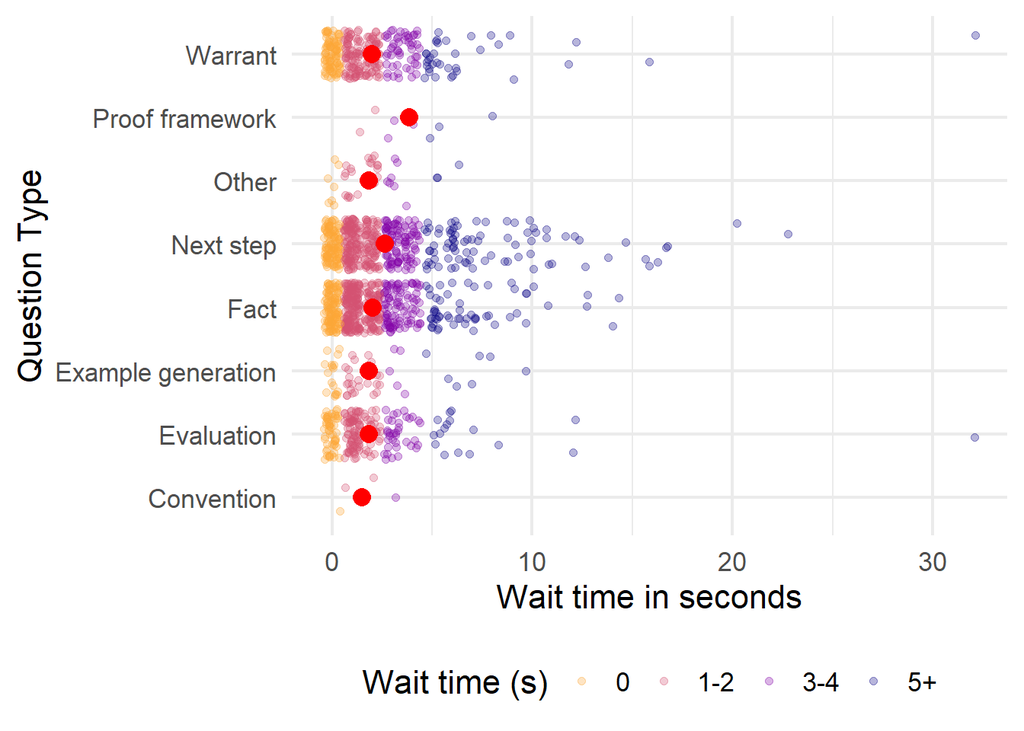

```r
qs_and_wait_time %>%
  filter(!code_name %in% c("Admin", "Understanding check")) %>%
  ggplot(aes(x = code_name)) +
  geom_jitter(aes(y = wait_time, colour = wait_time_bin), alpha = 0.3, size = 2, stroke = 0) +
  #geom_point(aes(y = num_q_mean, colour = course_level), alpha = 1, size = 3) +
  stat_summary(aes(y = wait_time), fun=mean, geom="point", shape=20, size=6, colour = "red", alpha = 1, position = position_nudge(x = 0))+
  scale_colour_viridis_d("Wait time (s)", end = 0.8, option = "plasma", direction = -1) +
  theme_minimal(base_size = 16) +
  theme(
    legend.position = "bottom"
  ) +
  labs(
    x = "Question Type",
    y = "Wait time in seconds"
  ) +
  coord_flip()
```

```r
ggsave("figs/FIG_Wait_times.pdf",width=30,height=15,units="cm",dpi=300)
```

## Summary statistics

This shows the mean (and SD) of the number of questions of each type and wait time **per lecture**.

```r
qs_and_wait_time_completed <- qs_and_wait_time %>%
  group_by(wait_time_bin, course, session, code_name) %>%
  summarise(
    num_qs = n(),
    .groups = "drop"
  ) %>%
  # make sure lectures with no questions are included, with counts of 0
  right_join(
    lec_cat %>%
      left_join(code_details, by = c("category" = "code")) %>%
      select(course, session, code_name) %>%
      expand_grid(
        qs_and_wait_time %>% select(wait_time_bin) %>% distinct()
      ),
    by = c("wait_time_bin", "course", "session", "code_name")
  ) %>%
  replace_na(list(num_qs = 0)) %>%
  filter(!code_name %in% c("Admin", "Understanding check"))

wait_times_summary <- qs_and_wait_time_completed %>%
  group_by(wait_time_bin, code_name) %>%
  summarise(
    n = n(),
    sum = sum(num_qs),
    num_qs_mean = mean(num_qs),
    num_qs_sd = sd(num_qs),
    .groups = "drop"
  )

wait_times_summary %>%
  mutate(
    mean_and_sd = case_when(
      is.na(num_qs_sd) ~ paste0(round(num_qs_mean, digits = 2), " "),
      TRUE ~ paste0(round(num_qs_mean, digits = 2), " (", round(num_qs_sd, digits = 2),")")
    )
  ) %>%
  select(code_name, wait_time_bin, mean_and_sd) %>%
  pivot_wider(
    names_from = wait_time_bin,
    values_from = mean_and_sd
  ) %>%
  kable(booktabs = T, caption = "Mean (sd)") %>%
  kable_styling(full_width = F)
```

Mean (sd)

| code_name | 0 | 1-2 | 3-4 | 5+ |
| --- | --- | --- | --- | --- |
| Convention | 0.01 (0.09) | 0.01 (0.17) | 0.01 (0.09) | 0 (0) |
| Evaluation | 0.4 (1.1) | 0.76 (1.55) | 0.26 (0.64) | 0.12 (0.41) |
| Example generation | 0.12 (0.49) | 0.18 (0.62) | 0.04 (0.22) | 0.05 (0.33) |
| Fact | 0.86 (1.66) | 1.84 (3.15) | 0.68 (1.41) | 0.41 (0.88) |
| Next step | 0.82 (2.11) | 1.43 (2.67) | 0.73 (1.4) | 0.6 (1.31) |
| Other | 0.05 (0.31) | 0.15 (0.64) | 0.05 (0.22) | 0.02 (0.15) |
| Proof framework | 0 (0) | 0.01 (0.12) | 0.02 (0.15) | 0.02 (0.19) |
| Warrant | 0.69 (1.44) | 0.91 (1.66) | 0.38 (0.73) | 0.26 (0.62) |

Proportion of all questions with given wait time:

```r
# Totals
wait_times_summary_totalsrow <- qs_and_wait_time_completed %>%
  # add up all the questions of any type in a given session
  group_by(wait_time_bin, course, session) %>%
  summarise(
    num_qs = sum(num_qs),
    .groups = "drop"
  ) %>%
  group_by(wait_time_bin) %>%
  summarise(
    n = n(),
    num_qs_mean = mean(num_qs),
    num_qs_sd = sd(num_qs),
    .groups = "drop"
  ) %>%
  ungroup() %>%
  mutate(code_name = "Total")

wait_times_summary_totalsrow %>%
  adorn_totals() %>%
  mutate(
    num_qs_prop = num_qs_mean / sum(num_qs_mean)*2,
    cell_entry = paste0(round(num_qs_mean, digits = 2), " (", round(num_qs_prop*100, digits = 0),"%)")
  ) %>%
  select(wait_time_bin, cell_entry) %>%
  basic_kable(booktabs = T)
```

| wait_time_bin | cell_entry |
| --- | --- |
| 0 | 2.95 (25%) |
| 1-2 | 5.3 (45%) |
| 3-4 | 2.17 (18%) |
| 5+ | 1.49 (13%) |
| Total | 11.91 (100%) |

This **per lecture** summary is analagous to Table 5 of Paoletti et al. (2018):

```r
counts_by_lecture_inc_totals_noAU <- read_csv("data/output-03-counts_by_lecture_inc_totals_noAU.csv")
```

```r
wait_times_summary_wide_table <- wait_times_summary %>%
  bind_rows(
    wait_times_summary_totalsrow
  ) %>%
  select(
    wait_time_bin,
    code_name,
    mean = num_qs_mean,
    sd = num_qs_sd
  ) %>%
  # add percentages of category
  group_by(code_name) %>%
  mutate(
    type_pc = round(mean / sum(mean) * 100, 0)
  ) %>%
  ungroup() %>%
  pivot_wider(
    names_from = wait_time_bin,
    values_from = c(mean, sd, type_pc),
    names_glue = "{wait_time_bin}_{.value}"
  ) %>%
  # add the totals for each category, from earlier table
  left_join(
    counts_by_lecture_inc_totals_noAU %>% group_by(code_name) %>% summarise(num_q_mean = mean(num_q)),
    by = "code_name"
  ) %>%
  arrange(if_else(code_name=="Total",1,0),-num_q_mean) %>%
  # sort the columns in alphabetical order
  select(code_name, num_q_mean, sort(tidyselect::peek_vars()))

options(knitr.kable.NA = '-')
wait_times_summary_wide_table %>%
    kable(booktabs = T,
          digits = 2,
          col.name = c("Question category",
                       "M",
                       rep(c("M", "SD", "% of cat"), 4))
    ) %>%
    kable_styling(full_width = T) %>%
    add_header_above(c(" " = 2, "0s" = 3, "1-2s" = 3, "3-4s" = 3, "5+s" = 3))
```

| Question category | M | 0s M | 0s SD | 0s % of cat | 1-2s M | 1-2s SD | 1-2s % of cat | 3-4s M | 3-4s SD | 3-4s % of cat | 5+s M | 5+s SD | 5+s % of cat |
| --- | --- | --- | --- | --- | --- | --- | --- | --- | --- | --- | --- | --- | --- |
| Fact | 3.79 | 0.86 | 1.66 | 23 | 1.84 | 3.15 | 48 | 0.68 | 1.41 | 18 | 0.41 | 0.88 | 11 |
| Next step | 3.58 | 0.82 | 2.11 | 23 | 1.43 | 2.67 | 40 | 0.73 | 1.40 | 20 | 0.60 | 1.31 | 17 |
| Warrant | 2.24 | 0.69 | 1.44 | 31 | 0.91 | 1.66 | 41 | 0.38 | 0.73 | 17 | 0.26 | 0.62 | 12 |
| Evaluation | 1.54 | 0.40 | 1.10 | 26 | 0.76 | 1.55 | 49 | 0.26 | 0.64 | 17 | 0.12 | 0.41 | 8 |
| Example generation | 0.39 | 0.12 | 0.49 | 32 | 0.18 | 0.62 | 45 | 0.04 | 0.22 | 9 | 0.05 | 0.33 | 13 |
| Other | 0.28 | 0.05 | 0.31 | 18 | 0.15 | 0.64 | 55 | 0.05 | 0.22 | 18 | 0.02 | 0.15 | 8 |
| Proof framework | 0.06 | 0.00 | 0.00 | 0 | 0.01 | 0.12 | 25 | 0.02 | 0.15 | 38 | 0.02 | 0.19 | 38 |
| Convention | 0.03 | 0.01 | 0.09 | 25 | 0.01 | 0.17 | 50 | 0.01 | 0.09 | 25 | 0.00 | 0.00 | 0 |
| Total | 11.91 | 2.95 | 4.39 | 25 | 5.30 | 6.66 | 45 | 2.17 | 2.77 | 18 | 1.49 | 2.39 | 13 |

**LaTeX table**

```r
wait_times_summary_wide_table %>%
    kable(booktabs = T,
          format = "latex",
          digits = 2,
          col.name = c("Question category",
                       "M",
                       rep(c("M", "SD", "% of cat"), 4))
    ) %>%
    kable_styling(full_width = T) %>%
    add_header_above(c(" " = 2, "0s" = 3, "1-2s" = 3, "3-4s" = 3, "5+s" = 3)) %>%
  cat()
```

```
##
## \begin{tabu} to \linewidth {>{\raggedright}X>{\raggedleft}X>{\raggedleft}X>{\raggedleft}X>{\raggedleft}X>{\raggedleft}X>{\raggedleft}X>{\raggedleft}X>{\raggedleft}X>{\raggedleft}X>{\raggedleft}X>{\raggedleft}X>{\raggedleft}X>{\raggedleft}X}
## \toprule
## \multicolumn{2}{c}{ } & \multicolumn{3}{c}{0s} & \multicolumn{3}{c}{1-2s} & \multicolumn{3}{c}{3-4s} & \multicolumn{3}{c}{5+s} \\
## \cmidrule(l{3pt}r{3pt}){3-5} \cmidrule(l{3pt}r{3pt}){6-8} \cmidrule(l{3pt}r{3pt}){9-11} \cmidrule(l{3pt}r{3pt}){12-14}
## Question category & M & M & SD & \% of cat & M & SD & \% of cat & M & SD & \% of cat & M & SD & \% of cat\\
## \midrule
## Fact & 3.79 & 0.86 & 1.66 & 23 & 1.84 & 3.15 & 48 & 0.68 & 1.41 & 18 & 0.41 & 0.88 & 11\\
## Next step & 3.58 & 0.82 & 2.11 & 23 & 1.43 & 2.67 & 40 & 0.73 & 1.40 & 20 & 0.60 & 1.31 & 17\\
## Warrant & 2.24 & 0.69 & 1.44 & 31 & 0.91 & 1.66 & 41 & 0.38 & 0.73 & 17 & 0.26 & 0.62 & 12\\
## Evaluation & 1.54 & 0.40 & 1.10 & 26 & 0.76 & 1.55 & 49 & 0.26 & 0.64 & 17 & 0.12 & 0.41 & 8\\
## Example generation & 0.39 & 0.12 & 0.49 & 32 & 0.18 & 0.62 & 45 & 0.04 & 0.22 & 9 & 0.05 & 0.33 & 13\\
## \addlinespace
## Other & 0.28 & 0.05 & 0.31 & 18 & 0.15 & 0.64 & 55 & 0.05 & 0.22 & 18 & 0.02 & 0.15 & 8\\
## Proof framework & 0.06 & 0.00 & 0.00 & 0 & 0.01 & 0.12 & 25 & 0.02 & 0.15 & 38 & 0.02 & 0.19 & 38\\
## Convention & 0.03 & 0.01 & 0.09 & 25 & 0.01 & 0.17 & 50 & 0.01 & 0.09 & 25 & 0.00 & 0.00 & 0\\
## Total & 11.91 & 2.95 & 4.39 & 25 & 5.30 & 6.66 & 45 & 2.17 & 2.77 & 18 & 1.49 & 2.39 & 13\\
## \bottomrule
## \end{tabu}
```

## As proportions of the overall number of questions

Those per lecture numbers are quite small and hard to interpret.

Instead, we work out the proportions more simply, as the proportion of overall number of questions. It gives the same percentages across the rows as the method above, e.g. 23% of Fact questions have a wait time of 0s.

```r
qs_and_wait_time_simple_summary <- qs_and_wait_time %>%
  filter(!code_name %in% c("Admin", "Understanding check")) %>%
  tabyl(code_name, wait_time_bin) %>%
  adorn_totals(c("row", "col")) %>%
  adorn_percentages("row") %>%
  adorn_pct_formatting(digits = 0) %>%
  adorn_ns(position = "front") %>%
  relocate(Total, .after = code_name) %>%
  # remove the percentage from the Total column, and sort by it
  mutate(Total = parse_number(str_replace(Total, " \\(.*", ""))) %>%
  arrange(code_name=="Total", -Total) %>%
  # Tidy up the column names
  rename("Question category" = code_name) %>%
  rename_with(~ paste(.x, "s (%)"), .cols = matches("\\d"))

qs_and_wait_time_simple_summary %>%
    basic_kable(booktabs = T, caption = "[Table 7 in the manuscript]. Number of questions of each type broken down by wait time.") %>%
    kable_styling(full_width = T)
```

[Table 7 in the manuscript]. Number of questions of each type broken down by wait time.

| Question category | Total | 0 s (%) | 1-2 s (%) | 3-4 s (%) | 5+ s (%) |
| --- | --- | --- | --- | --- | --- |
| Fact | 516 | 117 (23%) | 250 (48%) | 93 (18%) | 56 (11%) |
| Next step | 487 | 111 (23%) | 195 (40%) | 99 (20%) | 82 (17%) |
| Warrant | 304 | 94 (31%) | 124 (41%) | 51 (17%) | 35 (12%) |
| Evaluation | 210 | 54 (26%) | 103 (49%) | 36 (17%) | 17 (8%) |
| Example generation | 53 | 17 (32%) | 24 (45%) | 5 (9%) | 7 (13%) |
| Other | 38 | 7 (18%) | 21 (55%) | 7 (18%) | 3 (8%) |
| Proof framework | 8 | 0 (0%) | 2 (25%) | 3 (38%) | 3 (38%) |
| Convention | 4 | 1 (25%) | 2 (50%) | 1 (25%) | 0 (0%) |
| Total | 1620 | 401 (25%) | 721 (45%) | 295 (18%) | 203 (13%) |

**LaTeX table**

```r
qs_and_wait_time_simple_summary %>%
  kable(booktabs = T, format = "latex") %>%
  cat()
```

```
##
## \begin{tabular}{lrllll}
## \toprule
## Question category & Total & 0 s (\%) & 1-2 s (\%) & 3-4 s (\%) & 5+ s (\%)\\
## \midrule
## Fact & 516 & 117 (23\%) & 250 (48\%) & 93 (18\%) & 56 (11\%)\\
## Next step & 487 & 111 (23\%) & 195 (40\%) & 99 (20\%) & 82 (17\%)\\
## Warrant & 304 & 94 (31\%) & 124 (41\%) & 51 (17\%) & 35 (12\%)\\
## Evaluation & 210 & 54 (26\%) & 103 (49\%) & 36 (17\%) & 17  (8\%)\\
## Example generation & 53 & 17 (32\%) & 24 (45\%) & 5  (9\%) & 7 (13\%)\\
## \addlinespace
## Other & 38 & 7 (18\%) & 21 (55\%) & 7 (18\%) & 3  (8\%)\\
## Proof framework & 8 & 0  (0\%) & 2 (25\%) & 3 (38\%) & 3 (38\%)\\
## Convention & 4 & 1 (25\%) & 2 (50\%) & 1 (25\%) & 0  (0\%)\\
## Total & 1620 & 401 (25\%) & 721 (45\%) & 295 (18\%) & 203 (13\%)\\
## \bottomrule
## \end{tabular}
```

## Comparison with Paoletti et al. (2018)

Here we restrict to the courses that were deemed most comparable to those in the Paoletti et al. (2018) sample.

The proportions here are not markedly different from those in the full sample.

```r
adv_qs_and_wait_time_simple_summary <- qs_and_wait_time %>%
  # restrict to only those courses that were deemed "advanced mathematics"
  semi_join(
    anon_courses %>% filter(advanced == "yes"),
    by = c("course" = "anon_code")
  ) %>%
  filter(!code_name %in% c("Admin", "Understanding check")) %>%
  tabyl(code_name, wait_time_bin) %>%
  adorn_totals(c("row", "col")) %>%
  adorn_percentages("row") %>%
  adorn_pct_formatting(digits = 0) %>%
  adorn_ns(position = "front") %>%
  relocate(Total, .after = code_name) %>%
  # remove the percentage from the Total column, and sort by it
  mutate(Total = parse_number(str_replace(Total, " \\(.*", ""))) %>%
  arrange(code_name=="Total", -Total) %>%
  # Tidy up the column names
  rename("Question category" = code_name) %>%
  rename_with(~ paste(.x, "s (%)"), .cols = matches("\\d"))

adv_qs_and_wait_time_simple_summary %>%
    basic_kable(booktabs = T, caption = "For the proof-based courses only, number of questions of each type broken down by wait time.") %>%
    kable_styling(full_width = T)
```

For the proof-based courses only, number of questions of each type broken down by wait time.

| Question category | Total | 0 s (%) | 1-2 s (%) | 3-4 s (%) | 5+ s (%) |
| --- | --- | --- | --- | --- | --- |
| Next step | 401 | 94 (23%) | 154 (38%) | 81 (20%) | 72 (18%) |
| Fact | 291 | 77 (26%) | 136 (47%) | 42 (14%) | 36 (12%) |
| Warrant | 238 | 76 (32%) | 96 (40%) | 38 (16%) | 28 (12%) |
| Evaluation | 162 | 48 (30%) | 78 (48%) | 26 (16%) | 10 (6%) |
| Example generation | 40 | 15 (38%) | 16 (40%) | 5 (12%) | 4 (10%) |
| Other | 27 | 5 (19%) | 13 (48%) | 6 (22%) | 3 (11%) |
| Proof framework | 8 | 0 (0%) | 2 (25%) | 3 (38%) | 3 (38%) |
| Convention | 3 | 1 (33%) | 2 (67%) | 0 (0%) | 0 (0%) |
| Total | 1170 | 316 (27%) | 497 (42%) | 201 (17%) | 156 (13%) |

**LaTeX table**

```r
adv_qs_and_wait_time_simple_summary %>%
  kable(booktabs = T, format = "latex") %>%
  cat()
```

```
##
## \begin{tabular}{lrllll}
## \toprule
## Question category & Total & 0 s (\%) & 1-2 s (\%) & 3-4 s (\%) & 5+ s (\%)\\
## \midrule
## Next step & 401 & 94 (23\%) & 154 (38\%) & 81 (20\%) & 72 (18\%)\\
## Fact & 291 & 77 (26\%) & 136 (47\%) & 42 (14\%) & 36 (12\%)\\
## Warrant & 238 & 76 (32\%) & 96 (40\%) & 38 (16\%) & 28 (12\%)\\
## Evaluation & 162 & 48 (30\%) & 78 (48\%) & 26 (16\%) & 10  (6\%)\\
## Example generation & 40 & 15 (38\%) & 16 (40\%) & 5 (12\%) & 4 (10\%)\\
## \addlinespace
## Other & 27 & 5 (19\%) & 13 (48\%) & 6 (22\%) & 3 (11\%)\\
## Proof framework & 8 & 0  (0\%) & 2 (25\%) & 3 (38\%) & 3 (38\%)\\
## Convention & 3 & 1 (33\%) & 2 (67\%) & 0  (0\%) & 0  (0\%)\\
## Total & 1170 & 316 (27\%) & 497 (42\%) & 201 (17\%) & 156 (13\%)\\
## \bottomrule
## \end{tabular}
```

Going even further, if we get rid of 1C which dominates the sample, the wait times skew higher:

```r
non1c_adv_qs_and_wait_time <- qs_and_wait_time %>%
  semi_join(
    # restrict to only those courses that were deemed "advanced mathematics"
    anon_courses %>%
      filter(advanced == "yes") %>%
      # and further restrict to avoid the course 1C which has many lectures in the sample
      filter(anon_course != "1C"),
    by = c("course" = "anon_code")
  ) %>%
  filter(!code_name %in% c("Admin", "Understanding check"))

non1c_adv_qs_and_wait_time_simple_summary <- non1c_adv_qs_and_wait_time %>%
  tabyl(code_name, wait_time_bin) %>%
  adorn_totals(c("row", "col")) %>%
  adorn_percentages("row") %>%
  adorn_pct_formatting(digits = 0) %>%
  adorn_ns(position = "front") %>%
  relocate(Total, .after = code_name) %>%
  # remove the percentage from the Total column, and sort by it
  mutate(Total = parse_number(str_replace(Total, " \\(.*", ""))) %>%
  arrange(code_name=="Total", -Total) %>%
  # Tidy up the column names
  rename("Question category" = code_name) %>%
  rename_with(~ paste(.x, "s (%)"), .cols = matches("\\d"))

non1c_adv_qs_and_wait_time_simple_summary %>%
    basic_kable(booktabs = T, caption = "For the proof-based courses only, and excluding course 1C, number of questions of each type broken down by wait time.") %>%
    kable_styling(full_width = T)
```

For the proof-based courses only, and excluding course 1C, number of questions of each type broken down by wait time.

| Question category | Total | 0 s (%) | 1-2 s (%) | 3-4 s (%) | 5+ s (%) |
| --- | --- | --- | --- | --- | --- |
| Next step | 117 | 15 (13%) | 35 (30%) | 21 (18%) | 46 (39%) |
| Fact | 104 | 17 (16%) | 44 (42%) | 21 (20%) | 22 (21%) |
| Warrant | 47 | 11 (23%) | 15 (32%) | 11 (23%) | 10 (21%) |
| Evaluation | 39 | 10 (26%) | 20 (51%) | 6 (15%) | 3 (8%) |
| Example generation | 25 | 8 (32%) | 10 (40%) | 4 (16%) | 3 (12%) |
| Other | 10 | 1 (10%) | 6 (60%) | 3 (30%) | 0 (0%) |
| Proof framework | 4 | 0 (0%) | 1 (25%) | 2 (50%) | 1 (25%) |
| Total | 346 | 62 (18%) | 131 (38%) | 68 (20%) | 85 (25%) |

For reference, this subset of the sample has 26 lectures.

## Wait time and responses

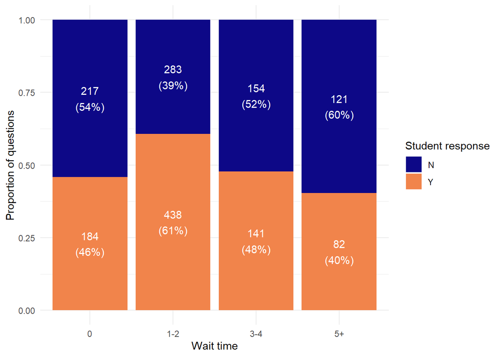

```r
wait_time_vs_response_tab <- all_qs_all_lecs %>%
  filter(!code_name %in% c("Admin", "Understanding check")) %>%
  filter(!is.na(code_name)) %>%
  mutate(
    wait_time_bin = case_when(
      wait_time == 0 ~ "0",
      wait_time <3 ~ "1-2",
      wait_time <5 ~ "3-4",
      wait_time >4 ~ "5+"
    )
  ) %>%
  count(wait_time_bin, student_response)

wait_time_vs_response_tab %>%
  group_by(wait_time_bin) %>%
  mutate(pct_label = str_glue("{n}\n({round(n / sum(n) * 100, 0)}%)")) %>%
  ggplot(aes(x = wait_time_bin, y = n, fill = student_response)) +
    geom_bar(position = "fill", stat = "identity") +
    geom_text(aes(label = pct_label), position = position_fill(vjust = 0.5), colour = "white") +
    scale_fill_viridis_d("Student response", begin = 0, end = 0.7, option = "plasma") +
    labs(x = "Wait time", y = "Proportion of questions")
```

```r
wait_time_vs_response_tab %>%
  pivot_wider(names_from = "student_response", values_from = "n") %>%
  adorn_totals(c("row", "col")) %>%
  adorn_percentages("row") %>%
  adorn_pct_formatting(digits = 0) %>%
  adorn_ns(position = "front") %>%
  relocate(Total, .after = wait_time_bin) %>%
  mutate(Total = parse_number(str_replace(Total, " \\(.*", ""))) %>%
  basic_kable(
    booktabs = T,
    caption = "Response rates for questions by wait time.",
    col.names = c("Wait time", "Total", "No", "Yes")
  ) %>%
  kable_styling(full_width = T) %>%
  add_header_above(c(" " = 2, "Student response" = 2))
```

Response rates for questions by wait time.

| Wait time | Total | Student response No | Student response Yes |
| --- | --- | --- | --- |
| 0 | 401 | 217 (54%) | 184 (46%) |
| 1-2 | 721 | 283 (39%) | 438 (61%) |
| 3-4 | 295 | 154 (52%) | 141 (48%) |
| 5+ | 203 | 121 (60%) | 82 (40%) |
| Total | 1620 | 775 (48%) | 845 (52%) |

Considering only questions not part of a chain:

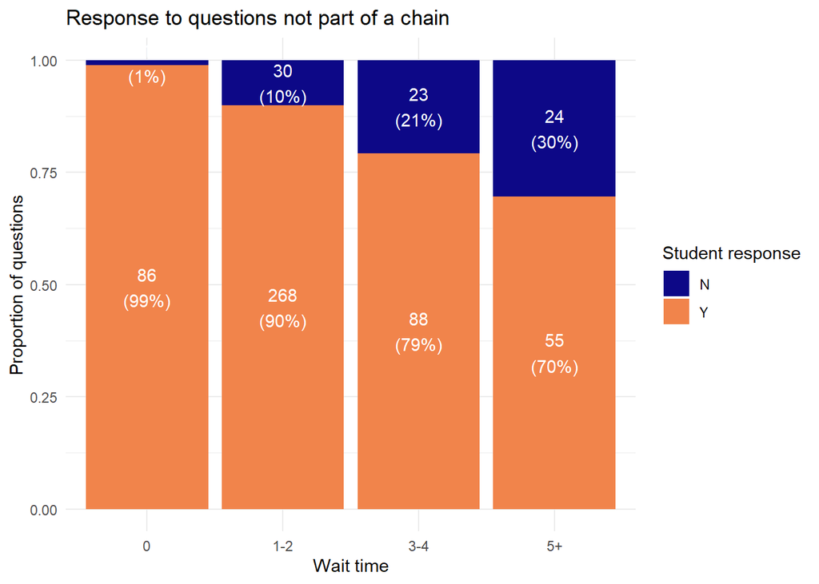

```r
wait_time_vs_response_tab_nochain <- all_qs_all_lecs %>%
  filter(!code_name %in% c("Admin", "Understanding check")) %>%
  filter(!is.na(code_name)) %>%
  mutate(
    wait_time_bin = case_when(
      wait_time == 0 ~ "0",
      wait_time <3 ~ "1-2",
      wait_time <5 ~ "3-4",
      wait_time >4 ~ "5+"
    )
  ) %>%
  filter(cluster_q == "N") %>%
  count(wait_time_bin, student_response)

wait_time_vs_response_tab_nochain %>%
  group_by(wait_time_bin) %>%
  mutate(pct_label = str_glue("{n}\n({round(n / sum(n) * 100, 0)}%)")) %>%
  ggplot(aes(x = wait_time_bin, y = n, fill = student_response)) +
    geom_bar(position = "fill", stat = "identity") +
    geom_text(aes(label = pct_label), position = position_fill(vjust = 0.5), colour = "white") +
    scale_fill_viridis_d("Student response", begin = 0, end = 0.7, option = "plasma") +
    labs(x = "Wait time", y = "Proportion of questions", title = "Response to questions not part of a chain")
```

```r
wait_time_vs_response_tab_nochain %>%
  pivot_wider(names_from = "student_response", values_from = "n") %>%
  adorn_totals(c("row", "col")) %>%
  adorn_percentages("row") %>%
  adorn_pct_formatting(digits = 0) %>%
  adorn_ns(position = "front") %>%
  relocate(Total, .after = wait_time_bin) %>%
  mutate(Total = parse_number(str_replace(Total, " \\(.*", ""))) %>%
  basic_kable(
    booktabs = T,
    caption = "Response rates for questions by wait time.",
    col.names = c("Wait time", "Total", "No", "Yes")
  ) %>%
  kable_styling(full_width = T) %>%
  add_header_above(c(" " = 2, "Student response" = 2))
```

Response rates for questions by wait time.

| Wait time | Total | Student response No | Student response Yes |
| --- | --- | --- | --- |
| 0 | 87 | 1 (1%) | 86 (99%) |
| 1-2 | 298 | 30 (10%) | 268 (90%) |
| 3-4 | 111 | 23 (21%) | 88 (79%) |
| 5+ | 79 | 24 (30%) | 55 (70%) |
| Total | 575 | 78 (14%) | 497 (86%) |

What about the position of the question in a chain?

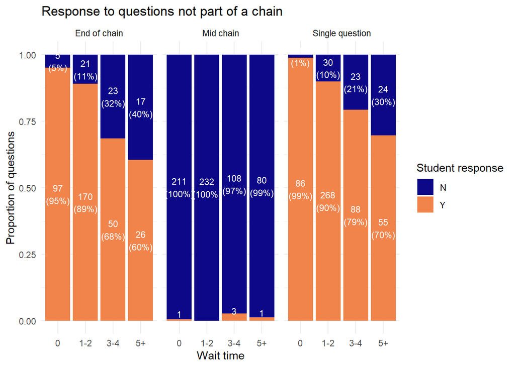

```r
wait_time_by_chain_position <- all_qs_all_lecs %>%
  filter(!code_name %in% c("Admin", "Understanding check")) %>%
  filter(!is.na(code_name)) %>%
  mutate(
    wait_time_bin = case_when(
      wait_time == 0 ~ "0",
      wait_time <3 ~ "1-2",
      wait_time <5 ~ "3-4",
      wait_time >4 ~ "5+"
    )
  ) %>%
  group_by(course, session, cluster_q) %>%
  mutate(
    chain_status = case_when(
      cluster_q == "N" ~ "Single question",
      row_number() == max(row_number()) ~ "End of chain",
      .default = "Mid chain"
    )
  ) %>%
  group_by(chain_status, wait_time_bin, student_response) %>%
  tally()

wait_time_by_chain_position %>%
  group_by(chain_status, wait_time_bin) %>%
  mutate(pct_label = str_glue("{n}\n({round(n / sum(n) * 100, 0)}%)")) %>%
  ggplot(aes(x = wait_time_bin, y = n, fill = student_response)) +
    geom_bar(position = "fill", stat = "identity") +
    geom_text(aes(label = pct_label), position = position_fill(vjust = 0.5), colour = "white", size = 3) +
    scale_fill_viridis_d("Student response", begin = 0, end = 0.7, option = "plasma") +
    labs(x = "Wait time", y = "Proportion of questions", title = "Response to questions not part of a chain") +
  facet_wrap(~ chain_status)
```

**Table of values**

```r
wait_time_by_chain_position %>%
  group_by(chain_status, wait_time_bin) %>%
  mutate(pct_label = str_glue("{round(n / sum(n) * 100, 0)}%")) %>%
  basic_kable()
```

| chain_status | wait_time_bin | student_response | n | pct_label |
| --- | --- | --- | --- | --- |
| End of chain | 0 | N | 5 | 5% |
| End of chain | 0 | Y | 97 | 95% |
| End of chain | 1-2 | N | 21 | 11% |
| End of chain | 1-2 | Y | 170 | 89% |
| End of chain | 3-4 | N | 23 | 32% |
| End of chain | 3-4 | Y | 50 | 68% |
| End of chain | 5+ | N | 17 | 40% |
| End of chain | 5+ | Y | 26 | 60% |
| Mid chain | 0 | N | 211 | 100% |
| Mid chain | 0 | Y | 1 | 0% |
| Mid chain | 1-2 | N | 232 | 100% |
| Mid chain | 3-4 | N | 108 | 97% |
| Mid chain | 3-4 | Y | 3 | 3% |
| Mid chain | 5+ | N | 80 | 99% |
| Mid chain | 5+ | Y | 1 | 1% |
| Single question | 0 | N | 1 | 1% |
| Single question | 0 | Y | 86 | 99% |
| Single question | 1-2 | N | 30 | 10% |
| Single question | 1-2 | Y | 268 | 90% |
| Single question | 3-4 | N | 23 | 21% |
| Single question | 3-4 | Y | 88 | 79% |
| Single question | 5+ | N | 24 | 30% |
| Single question | 5+ | Y | 55 | 70% |

### Response to questions with long wait time

```r
long_wait_time_single_qs <- all_qs_all_lecs %>%
  filter(!code_name %in% c("Admin", "Understanding check")) %>%
  filter(!is.na(code_name)) %>%
  filter(wait_time > 4) %>%
  filter(cluster_q == "N")
```

These are different perspectives on the 79 questions that were not part of a chain, and that had wait time of 5+ seconds.

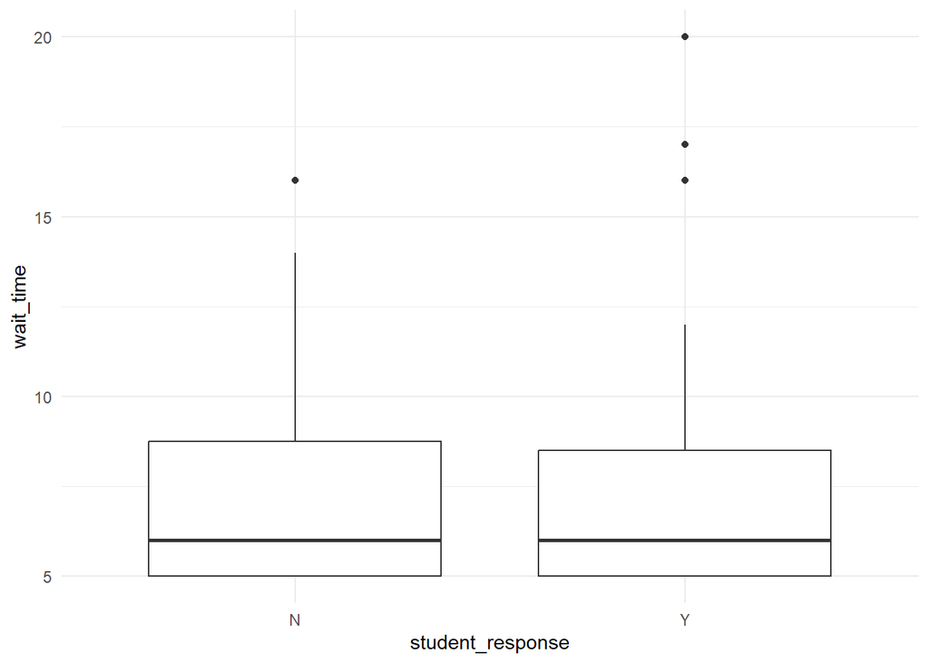

```r
long_wait_time_single_qs %>%
  ggplot(aes(x = student_response, y = wait_time)) +
  geom_boxplot()
```

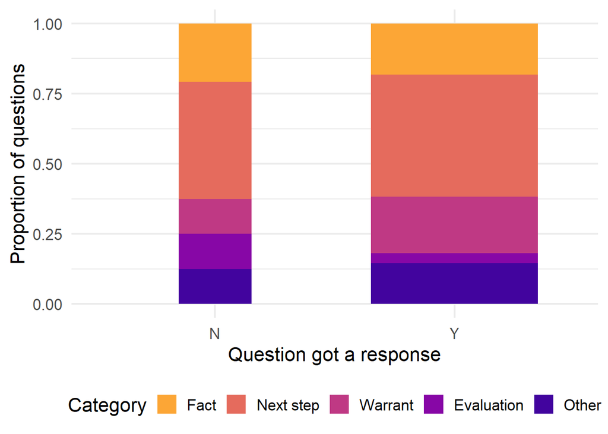

```r
long_wait_time_single_qs %>%
  group_by(category = collapsed_code, student_response) %>%
  tally() %>%
  group_by(student_response) %>%
  mutate(bar_width = sum(n)) %>%
  ungroup() %>%
  mutate(
    category = fct_relevel(as_factor(category), "Fact", "Next step", "Warrant", "Evaluation", "Other")
  ) %>%
  mutate(bar_width = bar_width / sum(n)) %>%
  ggplot(aes(x = student_response)) +
  geom_bar(aes(y = n, fill = category, width = bar_width), position = "fill", stat = "identity") +
  scale_fill_viridis_d("Category", begin = 0.1, end = 0.8, option = "plasma", direction = -1) +
  theme_minimal(base_size = 16) +
  theme(
    legend.position = "bottom",
  ) +
  labs(
    x = "Question got a response",
    y = "Proportion of questions"
  )
```

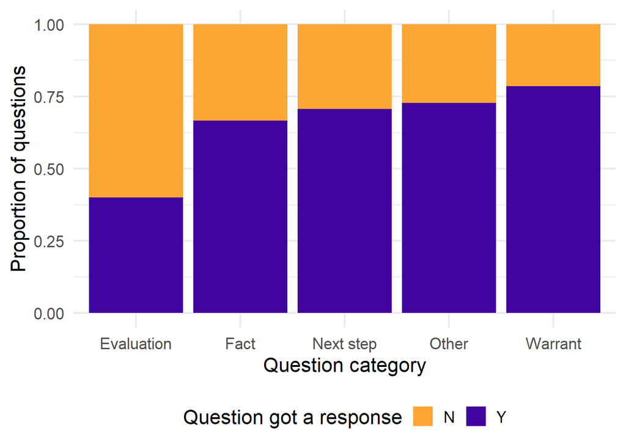

```r
long_wait_time_single_qs %>%
  group_by(category = collapsed_code, student_response) %>%
  tally() %>%
  ggplot(aes(x = category)) +
  geom_bar(aes(y = n, fill = student_response), position = "fill", stat = "identity") +
  scale_fill_viridis_d("Question got a response", begin = 0.1, end = 0.8, option = "plasma", direction = -1) +
  theme_minimal(base_size = 16) +
  theme(
    legend.position = "bottom",
  ) +
  labs(
    x = "Question category",
    y = "Proportion of questions"
  )
```

**Table with question details**

```r
long_wait_time_single_qs %>%
  select(course, session, student_response, code_name, question, wait_time) %>%
  arrange(wait_time) %>%
  basic_kable()
```

| course | session | student_response | code_name | question | wait_time |
| --- | --- | --- | --- | --- | --- |
| 1A_L1 | S4 | Y | Next step | Which theorem can we use here? | 5 |
| 2B_L10 | S1 | Y | Fact | someone else? | 5 |
| 2B_L10 | S1 | Y | Fact | how many elements are in the stabiliser of x in this example? | 5 |
| 3C_L13 | S1 | Y | Evaluation | Can I invert the matrix psi? | 5 |
| 3C_L13 | S1 | Y | Warrant | So why can I invert the matrix psi? | 5 |
| 1C_L15 | S6 | Y | Fact | What’s that matrix? | 5 |
| 2B_L10 | S3 | Y | Next step | Someone tell me something else about the centre of G. | 5 |
| 1C_L16 | S9 | N | Warrant | If the coefficient matrix has rank 2, then we’re told there’s always a solution - so anyone see this? [Asking for a justification] | 5 |
| 1C_L17 | S1 | Y | Next step | So how can we find that vector? | 5 |
| 1C_L17 | S2 | N | Example generation | Any other ‘others’? [Other possibilities for number of points of intersection of two planes] | 5 |
| 1A_L2 | S2 | N | Next step | Anybody got any better suggestions? | 5 |
| 1C_L17 | S10 | N | Other | What colour is that banana? | 5 |
| 1C_L17 | S10 | Y | Warrant | Why must this be linearly dependent? | 5 |
| 1C_L17 | S5 | N | Fact | and whats alpha? | 5 |
| 1C_L17 | S5 | Y | Warrant | would somebody who voted true like to justify why they voted true? | 5 |
| 1C_L16 | S3 | Y | Warrant | Ok. | 5 |
| 1C_L17 | S4 | Y | Proof framework | any suggestions? | 5 |
| 1C_L17 | S4 | Y | Proof framework | how do we prove that the span of u, v and w is the same as the span of u, v and the vector w+2u-v? | 5 |
| 1C_L17 | S3 | N | Next step | how would you turn these expressions into a set of equations to solve? | 5 |
| 4A_L10 | S3 | Y | Next step | Tell me some things about this intersection | 5 |
| 4A_L10 | S3 | Y | Next step | There’s one more thing I know about it | 5 |
| 4A_L10 | S2 | Y | Warrant | Good? | 5 |
| 4A_L10 | S2 | Y | Warrant | Why? | 5 |
| 4A_L10 | S2 | Y | Fact | Where else does it live? | 5 |
| 4A_L10 | S2 | N | Fact | What is the kernel of pi? | 5 |
| 4A_L10 | S2 | N | Fact | So theta inverse of theta of 15Z is what? | 5 |
| 4A_L10 | S2 | Y | Fact | If you met this group in a dark alley, what would you want to call it? | 5 |
| 1F_L14 | S2 | Y | Fact | What is this showing me? | 5 |
| 1F_L14 | S4 | Y | Fact | Would you expect the RMSE to be higher for your training data or your testing data? | 5 |
| 1D_L17 | S4 | N | Next step | So how could we find the real and imaginary part of this complex number and write those roots in cartesian form? | 5 |
| 1C_L15 | S1 | N | Warrant | Would anyone like to respond to that? | 6 |
| 2A_L22 | S3 | Y | Example generation | Has anyone got anything related to that in the same family? | 6 |
| 2A_L22 | S3 | Y | Next step | Any thoughts on this? | 6 |
| 3D_L20 | S3 | Y | Next step | Can anyone tell me what the solution of this is? | 6 |
| 1C_L16 | S13 | N | Other | What do you think the next question will be? | 6 |
| 1C_L17 | S1 | Y | Fact | What happens in the general case when c is non-zero? [Is the vector parallel/perpendicular/neither to the line?] | 6 |
| 1E_L19 | S1 | N | Evaluation | are these two equal? | 6 |
| 1C_L17 | S5 | Y | Fact | if gamma is c, what is beta? | 6 |
| 1C_L17 | S4 | Y | Next step | so how would we solve a system of equations? | 6 |
| 1C_L17 | S4 | Y | Warrant | any suggestions as to why it is or isnt a spanning set? | 6 |
| 4A_L10 | S3 | Y | Evaluation | What do you think? | 6 |
| 1D_L17 | S1 | N | Next step | Anything else? | 6 |
| 4A_L10 | S4 | N | Next step | So what do I do? | 6 |
| 4A_L10 | S4 | Y | Warrant | Why do R1 divide R2? | 6 |
| 1D_L17 | S4 | Y | Next step | So what do we do next? | 6 |
| 2A_L22 | S3 | Y | Example generation | Anything else at all? | 7 |
| 1D_L21 | S4 | Y | Example generation | What’s a counterexample? | 7 |
| 1D_L21 | S4 | Y | Next step | So tell me how I should prove this using the injection lemma. | 7 |
| 1C_L17 | S8 | Y | Next step | it<92>s a property of this set, so what? | 7 |
| 1E_L19 | S4 | N | Evaluation | Is it possible to do it? [This matrix multiplication] | 7 |
| 1C_L17 | S3 | Y | Next step | anything else we can do to answer this question? | 7 |
| 1D_L17 | S1 | N | Fact | The right hand side? | 7 |
| 4A_L10 | S2 | Y | Fact | So what’s 15Z intersect 12Z? | 7 |
| 4A_L10 | S4 | N | Next step | What do I know about the image of 123? | 7 |
| 1D_L17 | S2 | Y | Next step | What could we do to the original statement to make that true? | 7 |
| 2B_L10 | S1 | Y | Proof framework | [not using the orbit stabiliser theorem] how do you prove this? | 8 |
| 1D_L21 | S4 | Y | Example generation | What’s an example? | 8 |
| 1A_L5 | S1 | N | Warrant | Can someone give me an argument for this? | 8 |
| 1D_L17 | S1 | Y | Next step | Any suggestions of the first thing that we might do to solve this problem? | 8 |
| 2B_L10 | S3 | Y | Next step | So what do I know about the centraliser? | 9 |
| 2B_L10 | S3 | Y | Next step | But if the centraliser of little g is the whole group, then where does little g live by definition? | 9 |
| 1C_L15 | S8 | Y | Warrant | Yeah? | 9 |
| 3A_L11 | S1 | Y | Example generation | functions from R to R - can anyone think of a basis? | 10 |
| 2B_L10 | S2 | Y | Next step | Somehow we want to use that p is prime, right? | 10 |
| 1D_L17 | S4 | Y | Next step | What do you notice about the coefficients in these polynomials? | 10 |
| 1D_L21 | S2 | N | Next step | Ok so now we just have to count how many things are not divisible by three. How might we do that? | 11 |
| 1C_L17 | S9 | Y | Next step | What can you tell me about solutions to this system? | 11 |
| 2A_L22 | S1 | N | Evaluation | and what about c)? [can c) be modelled by a binomial distribution?] | 12 |
| 2B_L10 | S2 | Y | Warrant | So why is this? | 12 |
| 2B_L10 | S1 | Y | Next step | so what are some useful facts [to help prove the theorem]? | 12 |
| 2B_L10 | S1 | Y | Next step | I want to show that g inverse k is in h, how do I tell if an element is in h or not? | 12 |
| 2B_L10 | S2 | N | Next step | It’s not quite p-1 but there’s a p-1 in it | 13 |
| 1D_L21 | S3 | N | Fact | Given a single permutation pq, so an order 6 permutation, how many of these pairs will that permutation appear in? | 13 |
| 1D_L17 | S3 | N | Next step | What do you think will happen to this blue curve if I change the square to the cube? | 14 |
| 1C_L17 | S1 | Y | Next step | How might we do that? [Use what we know about the dot product to resolve this question] | 16 |
| 1C_L17 | S5 | N | Next step | so how are we going to do that? | 16 |
| 4A_L10 | S4 | Y | Warrant | Why do we have to go back to step 1 finitely many times? | 16 |
| 1D_L17 | S4 | Y | Next step | So what about the argument? | 17 |
| 1D_L17 | S1 | Y | Next step | So how do we proceed from here? | 20 |